# Viabilidad 20

una aplicación de gestión por suscripción: umbrales de precio, volumen y coste variable; escenarios; inflación 4%

# Enunciado

Una empresa estudia invertir en una aplicación de gestión por suscripción (datos adjuntos; mismas hipótesis contables que en el caso base: amortización lineal hasta el valor residual, circulante como fracción de las ventas aportado al principio de cada año y recuperado al final, valor residual cobrado por su valor contable). Antes de decidir, la dirección quiere saber *cuánto pueden equivocarse* las previsiones sin que el proyecto deje de ser viable.

1. Calcule los flujos de caja libre y el VAN del caso base.

2. Umbrales de rentabilidad: ¿qué precio mínimo, qué volumen mínimo del año 1 y qué coste variable máximo hacen el VAN igual a cero (manteniendo lo demás)? Exprese cada uno como variación porcentual respecto al caso base. ¿A qué variable es más sensible el proyecto?

3. Escenarios: pesimista (precio −10 %, unidades −10 %, costes fijos +10 %), base y optimista (precio +10 %, unidades +10 %, costes fijos −10 %). VAN y TIR de cada uno.

4. Los datos están en euros constantes. Si se espera una inflación del 4% anual que afecta por igual a precios y costes, ¿cómo deben construirse los flujos en euros corrientes y qué tasa nominal hay que usar para que el VAN no cambie? Compruébelo (relación de Fisher).

Tabla 1: Datos del caso

| parametro | valor |
| --- | --- |
| inversión inicial (k€) | 860.00 |
| vida del proyecto (años) | 6.00 |
| precio (€ por suscripcione) | 0.44 |
| suscripciones vendidas el año 1 | 2000.00 |
| crecimiento anual de las unidades | 0.00 |
| coste variable unitario (€) | 0.10 |
| costes fijos anuales (k€) | 345.00 |
| valor residual al final (k€) | 45.00 |
| circulante necesario (fracción de las ventas del año) | 0.05 |
| tipo impositivo | 0.25 |
| tasa de descuento | 0.12 |

# Resolución

## Apartado 1

1. Calcule los flujos de caja libre y el VAN del caso base.

Tabla 2: Flujos de caja libre del proyecto (k€)

| año | 0 | 1 | 2 | 3 | 4 | 5 | 6 |
| --- | --- | --- | --- | --- | --- | --- | --- |
| unidades | 0.0 | 2000.0 | 2000.0 | 2000.0 | 2000.0 | 2000.0 | 2000.0 |
| ventas | 0.0 | 880.0 | 880.0 | 880.0 | 880.0 | 880.0 | 880.0 |
| costes variables | 0.0 | 200.0 | 200.0 | 200.0 | 200.0 | 200.0 | 200.0 |
| costes fijos | 0.0 | 345.0 | 345.0 | 345.0 | 345.0 | 345.0 | 345.0 |
| EBITDA | 0.0 | 335.0 | 335.0 | 335.0 | 335.0 | 335.0 | 335.0 |
| amortización | 0.0 | 135.8 | 135.8 | 135.8 | 135.8 | 135.8 | 135.8 |
| BAI | 0.0 | 199.2 | 199.2 | 199.2 | 199.2 | 199.2 | 199.2 |
| impuesto | 0.0 | 49.8 | 49.8 | 49.8 | 49.8 | 49.8 | 49.8 |
| BDI | 0.0 | 149.4 | 149.4 | 149.4 | 149.4 | 149.4 | 149.4 |
| + amortización | 0.0 | 135.8 | 135.8 | 135.8 | 135.8 | 135.8 | 135.8 |
| − Δ circulante | -44.0 | -0.0 | -0.0 | -0.0 | -0.0 | -0.0 | 44.0 |
| − inversión | -860.0 | -0.0 | -0.0 | -0.0 | -0.0 | -0.0 | -0.0 |
| + valor residual | 0.0 | 0.0 | 0.0 | 0.0 | 0.0 | 0.0 | 45.0 |
| FCL | -904.0 | 285.2 | 285.2 | 285.2 | 285.2 | 285.2 | 374.2 |

Siglas: EBITDA, resultado antes de intereses, impuestos y amortizaciones; BAI, beneficio antes de impuestos; BDI, beneficio después de impuestos; FCL, flujo de caja libre (lo que el proyecto deja disponible cada año, en k€). Cálculo detallado del año 1 y de los años 0 y n:

- Ventas_1 = unidades × precio = 2000.0 × 0.44 = 880.0; costes variables = 2000.0 × 0.1 = 200.0; EBITDA_1 = 880.0 − 200.0 − 345.0 = 335.0.

- Amortización anual = (I0 − VR)/n = (860 − 45)/6 = 135.8; BAI_1 = 335.0 − 135.8 = 199.2; impuesto_1 = 0.25 × 199.2 = 49.8; BDI_1 = 199.2 − 49.8 = 149.4.

- Circulante (se aporta al principio de cada año, es decir, al final del anterior): en t = 0 el del año 1, 0.05 × 880.0 = 44.0; en cada momento t = 1…5, el aumento que necesitan las ventas del año siguiente, 0.05 × (ventas_t+1 − ventas_t) (en t = 1: 0.05 × (880.0 − 880.0) = 0.0); en t = 6 se recupera todo el circulante acumulado, 0.05 × 880.0 = 44.0.

- FCL_0 = BDI + amortización − Δ circulante − inversión + valor residual = 0.0 + 0.0 − 44.0 − 860.0 + 0.0 = **−904.0**; FCL_1 = BDI + amortización − Δ circulante − inversión + valor residual = 149.4 + 135.8 + 0.0 + 0.0 + 0.0 = **285.2**; FCL_6 = BDI + amortización − Δ circulante − inversión + valor residual = 149.4 + 135.8 + 44.0 + 0.0 + 45.0 = **374.2**.

VAN = Σ flujo_t/(1 + k)^t = −904.0 + 285.2/1.12¹ + 285.2/1.12² + 285.2/1.12³ + 285.2/1.12⁴ + 285.2/1.12⁵ + 374.2/1.12⁶ = −904.0 + 254.7 + 227.4 + 203.0 + 181.3 + 161.8 + 189.6 = **313.7 k€**.

La TIR es la tasa que anula el VAN. Probando tasas: VAN(23%) = 3.6 k€ y VAN(24%) = −18.1 k€ tienen signo distinto, así que la TIR está entre 23% y 24%; interpolando linealmente, TIR ≈ 23% + 1 % × 3.6/(3.6 − (−18.1)) = 23.17%. Afinando (bisección, o =TIR(rango de flujos) en la hoja de cálculo): **TIR = 23.16%**. Comprobación: VAN(23.16%) = 0.0000 ≈ 0.

**Respuesta:** VAN del caso base = 313.7 k€ (TIR 23.16%): viable.

## Apartado 2

2. Umbrales de rentabilidad: ¿qué precio mínimo, qué volumen mínimo del año 1 y qué coste variable máximo hacen el VAN igual a cero (manteniendo lo demás)? Exprese cada uno como variación porcentual respecto al caso base. ¿A qué variable es más sensible el proyecto?

Cada umbral es el valor de la variable x que hace VAN(x) = 0 con las demás fijas. El VAN es casi lineal en cada variable, así que el umbral se aproxima bien con una regla de tres: VAN(x) ≈ VAN_base + (x − x_base) · ΔVAN/Δx, donde ΔVAN/Δx se mide cambiando la variable un 1 %; después se afina por bisección y se comprueba que el VAN en el umbral es 0. La sensibilidad se lee en la variación porcentual que anula el VAN: cuanto menor, más frágil es el proyecto frente a esa variable.

|  | caso base | ΔVAN por unidad de la variable | umbral ≈ base − VAN / pendiente | umbral exacto (VAN = 0) | VAN en el umbral | variación admisible |
| --- | --- | --- | --- | --- | --- | --- |
| precio | 0.440 | 6117.77 | 0.44 − 313.7/(6117.77) = 0.389 | 0.389 | 0.0000 | -11.7% |
| unidades año 1 | 2000.000 | 1.04 | 2000 − 313.7/(1.04) = 1697.657 | 1697.657 | 0.0000 | -15.1% |
| coste variable | 0.100 | -6167.11 | 0.1 − 313.7/(−6167.11) = 0.151 | 0.151 | 0.0000 | +50.9% |

**Respuesta:** precio: mínimo 0.389 (-11.7% respecto a 0.44); unidades año 1: mínimo 1697.657 (-15.1% respecto a 2000); coste variable: máximo 0.151 (+50.9% respecto a 0.1). El proyecto es más sensible a la variable **precio**: basta una variación del -11.7% para anular el VAN. El diagrama de araña muestra lo mismo: la recta más inclinada (en % de variación) es la de la variable más sensible.

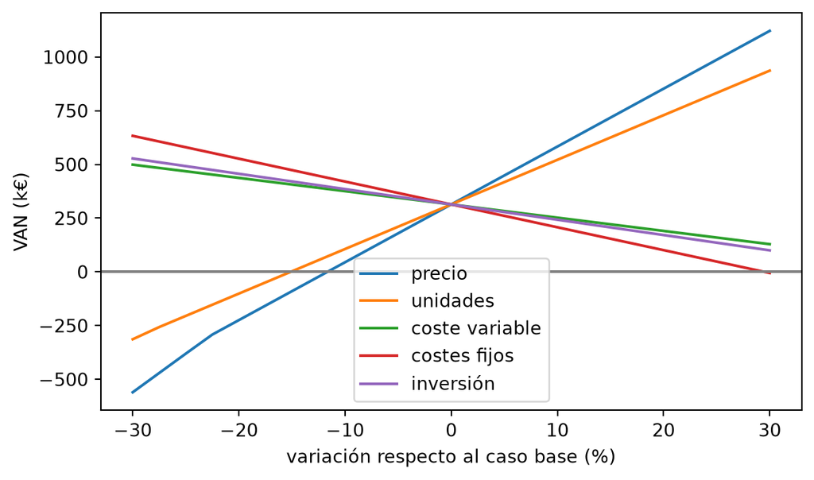

Figura 1: VAN frente a la variación de cada variable (diagrama de araña)

## Apartado 3

3. Escenarios: pesimista (precio −10 %, unidades −10 %, costes fijos +10 %), base y optimista (precio +10 %, unidades +10 %, costes fijos −10 %). VAN y TIR de cada uno.

Cada escenario repite el modelo completo con los tres datos cambiados a la vez; la tabla da sus flujos de caja libre y, debajo, el VAN término a término y la TIR.

| año | 0 | 1 | 2 | 3 | 4 | 5 | 6 |
| --- | --- | --- | --- | --- | --- | --- | --- |
| pesimista | -895.6 | 148.9 | 148.9 | 148.9 | 148.9 | 148.9 | 229.6 |
| base | -904.0 | 285.2 | 285.2 | 285.2 | 285.2 | 285.2 | 374.2 |
| optimista | -913.2 | 434.7 | 434.7 | 434.7 | 434.7 | 434.7 | 532.9 |

|  | VAN (k€) | TIR |
| --- | --- | --- |
| pesimista | -242.5 | 2.32% |
| base | 313.7 | 23.16% |
| optimista | 923.7 | 42.45% |

- pesimista (precio 0.396, unidades 1800, costes fijos 379.5): VAN = Σ flujo_t/(1 + k)^t = −895.6 + 148.9/1.12¹ + 148.9/1.12² + 148.9/1.12³ + 148.9/1.12⁴ + 148.9/1.12⁵ + 229.6/1.12⁶ = −895.6 + 133.0 + 118.7 + 106.0 + 94.6 + 84.5 + 116.3 = **−242.5 k€**; TIR = 2.32%.

- optimista (precio 0.484, unidades 2200, costes fijos 310.5): VAN = Σ flujo_t/(1 + k)^t = −913.2 + 434.7/1.12¹ + 434.7/1.12² + 434.7/1.12³ + 434.7/1.12⁴ + 434.7/1.12⁵ + 532.9/1.12⁶ = −913.2 + 388.1 + 346.5 + 309.4 + 276.2 + 246.7 + 270.0 = **923.7 k€**; TIR = 42.45%.

**Respuesta:** VAN y TIR: pesimista -242.5 k€ y 2.32%; base 313.7 k€ y 23.16%; optimista 923.7 k€ y 42.45%. El escenario pesimista destruye la viabilidad (su TIR queda por debajo de la tasa del 12%). Los escenarios combinan desviaciones simultáneas, que es lo que ocurre en la práctica (un mal año afecta a precio y volumen a la vez); el análisis de una variable cada vez las subestima.

## Apartado 4

4. Los datos están en euros constantes. Si se espera una inflación del 4% anual que afecta por igual a precios y costes, ¿cómo deben construirse los flujos en euros corrientes y qué tasa nominal hay que usar para que el VAN no cambie? Compruébelo (relación de Fisher).

En euros corrientes, todo importe que sigue a los precios se multiplica en el año t por (1 + π)^t (ventas, costes variables y fijos y, con ellas, el circulante); la amortización y el valor residual, que dependen del precio de compra, no cambian. Esos flujos se descuentan a la tasa nominal, que incluye la inflación: relación de Fisher, (1 + k_nominal) = (1 + k_real)(1 + π).

| año | 0 | 1 | 2 | 3 | 4 | 5 | 6 |
| --- | --- | --- | --- | --- | --- | --- | --- |
| euros constantes | -904.0 | 285.2 | 285.2 | 285.2 | 285.2 | 285.2 | 374.2 |
| euros corrientes | -905.8 | 293.4 | 303.8 | 314.6 | 325.8 | 337.5 | 452.5 |

k_nominal = (1 + 0.12)(1 + 0.04) − 1 = 16.48%. Flujos corrientes descontados a la tasa nominal: VAN = Σ flujo_t/(1 + k)^t = −905.8 + 293.4/1.1648¹ + 303.8/1.1648² + 314.6/1.1648³ + 325.8/1.1648⁴ + 337.5/1.1648⁵ + 452.5/1.1648⁶ = −905.8 + 251.9 + 223.9 + 199.1 + 177.0 + 157.4 + 181.2 = **284.7 k€**. **Respuesta:** los flujos corrientes se construyen inflando cada año precios y costes con (1 + 0.04)^t y se descuentan al 16.48%. Con ello el VAN es 284.7 k€, frente a 313.7 con flujos constantes y tasa real: no coinciden exactamente porque no todo crece con la inflación: la amortización (y su ahorro fiscal) y el valor residual son importes nominales fijos, y el circulante crece con las ventas nominales; la inflación perjudica al proyecto vía impuestos y circulante (-28.9 k€). El error grave sería mezclar: flujos corrientes con tasa real daría 450.2 k€, un VAN inflado.